# Indian Liver Patients

Octavio M.

11 June 2019

# **General Overview**

[figure not shown]

This project is part of the Professional Certification of HarvardX: Data Science. The main objective of this to analize one data base and use some ML. First we are going to start with a short introducction, then the given dataset will be prepared and get ready for a data analysis that will be carried out to acomplish the main goal and develop a machine learning (ML) algorithm that will help us to analize the Indian Liver Patients. After that the results will be explained and it will help to make some conclusions.

## *Introduction*

This project will examine data from liver patients especially concentrating on the relations between a list of key liver indicators, age, gender and then try to use them to predict liver disease.

Here is important to know that if we detect **early signs of liver disease**, we can save a lot of lifes. We know that the models have limitations and some errors, but they help us a lot.

In this project, the possibility of find early signs of liver disease with the variables we said before can help to decrease costs and help to improve the quality of life.

## *Data*

The Liver dataset is automatically downloaded

```r
if(!require(tidyverse)) install.packages("tidyverse", repos = "http://cran.us.r-project.org")
if(!require(caTools)) install.packages("caTools", repos = "http://cran.us.r-project.org")
if(!require(pscl)) install.packages("pscl", repos = "http://cran.us.r-project.org")

liver_data <- read.csv("https://archive.ics.uci.edu/ml/machine-learning-databases/00225/Indian%20Liver%20Patient%20Dataset%20(ILPD).csv",
    header = FALSE)
colnames(liver_data) <- c("Age", "Sex", "Tot_Bil", "Dir_Bil", "Alkphos", "Alamine",
    "Aspartate", "Tot_Prot", "Albumin", "A_G_Ratio", "Disease")
liver_data$Sex <- (ifelse(liver_data$Sex == "Male", "M", "F"))  #made shorter
liver_data$Disease <- as.numeric(ifelse(liver_data$Disease == 2, 0, 1))  #converted to zeros and ones
```

# **Analysis**

## *Data*

First of all we need to know a little bit of our data set. Down are the first rows of the *Liver Data* subset. The subset contain eleven variables **Age**, **Total_Bilirubin**, **Gender**, **Direct_Bilirubin**, **Alkaline_Phosphotase**,**Alamine_Aminotransferase**,**Aspartate_Aminotransferase**,**Total_Protiens**,**Albumin**, **Albumin_and_Globulin_Ratio** and **Dataset**. Each row represent a single patient.

```
##   Age Sex Tot_Bil Dir_Bil Alkphos Alamine Aspartate Tot_Prot Albumin
## 1  65   F     0.7     0.1     187      16        18      6.8     3.3
## 2  62   M    10.9     5.5     699      64       100      7.5     3.2
## 3  62   M     7.3     4.1     490      60        68      7.0     3.3
## 4  58   M     1.0     0.4     182      14        20      6.8     3.4
## 5  72   M     3.9     2.0     195      27        59      7.3     2.4
## 6  46   M     1.8     0.7     208      19        14      7.6     4.4
##   A_G_Ratio Disease
## 1      0.90       1
## 2      0.74       1
## 3      0.89       1
## 4      1.00       1
## 5      0.40       1
## 6      1.30       1
```

A summary of the Data:

```
##       Age            Sex               Tot_Bil          Dir_Bil
##  Min.   : 4.00   Length:583         Min.   : 0.400   Min.   : 0.100
##  1st Qu.:33.00   Class :character   1st Qu.: 0.800   1st Qu.: 0.200
##  Median :45.00   Mode  :character   Median : 1.000   Median : 0.300
##  Mean   :44.75                      Mean   : 3.299   Mean   : 1.486
##  3rd Qu.:58.00                      3rd Qu.: 2.600   3rd Qu.: 1.300
##  Max.   :90.00                      Max.   :75.000   Max.   :19.700
##
##     Alkphos          Alamine          Aspartate         Tot_Prot
##  Min.   :  63.0   Min.   :  10.00   Min.   :  10.0   Min.   :2.700
##  1st Qu.: 175.5   1st Qu.:  23.00   1st Qu.:  25.0   1st Qu.:5.800
##  Median : 208.0   Median :  35.00   Median :  42.0   Median :6.600
##  Mean   : 290.6   Mean   :  80.71   Mean   : 109.9   Mean   :6.483
##  3rd Qu.: 298.0   3rd Qu.:  60.50   3rd Qu.:  87.0   3rd Qu.:7.200
##  Max.   :2110.0   Max.   :2000.00   Max.   :4929.0   Max.   :9.600
##
##     Albumin        A_G_Ratio         Disease
##  Min.   :0.900   Min.   :0.3000   Min.   :0.0000
##  1st Qu.:2.600   1st Qu.:0.7000   1st Qu.:0.0000
##  Median :3.100   Median :0.9300   Median :1.0000
##  Mean   :3.142   Mean   :0.9471   Mean   :0.7136
##  3rd Qu.:3.800   3rd Qu.:1.1000   3rd Qu.:1.0000
##  Max.   :5.500   Max.   :2.8000   Max.   :1.0000
##                  NA's   :4
```

### **Age**

A big part of the patiens is **in the range of age of 25 and 62 years old**.

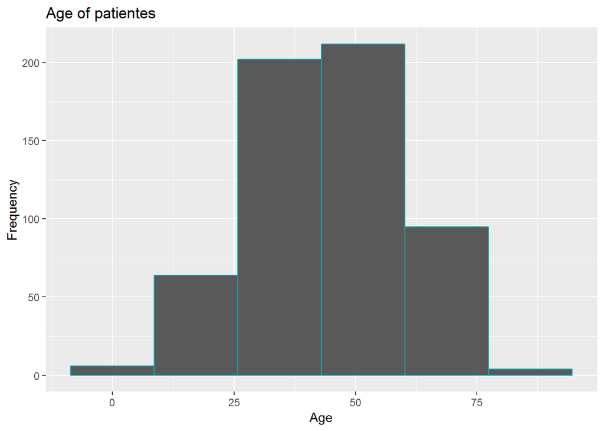

```r
liver_data %>%
ggplot(aes(Age)) +
geom_histogram(bins = 6, color = "#00AFBB") +
xlab("Age") +
ylab("Frequency") +
ggtitle("Age of patientes")
```

```r
liver_data %>%
group_by(Sex,Disease)%>%
   summarise (n = n())
```

| Sex | Disease | n |
| --- | --- | --- |
| F | 0 | 50 |
| F | 1 | 92 |
| M | 0 | 117 |
| M | 1 | 324 |

### **Total Bilirubin**

Bilirubin is a prodcut of the catabolism, is one of the substance that the liver have the job to filter. Elevated levels of this can be a hint of liver disease, it cause the change of color in the skin (yellow).

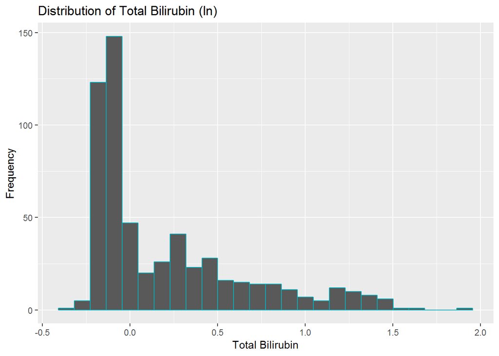

```r
liver_data %>%
ggplot(aes(log10(Tot_Bil))) +
geom_histogram(bins = 26, color = "#00AFBB") +
xlab("Total Bilirubin") +
ylab("Frequency") +
ggtitle("Distribution of Total Bilirubin (ln)")
```

### **Direct Bilirubin**

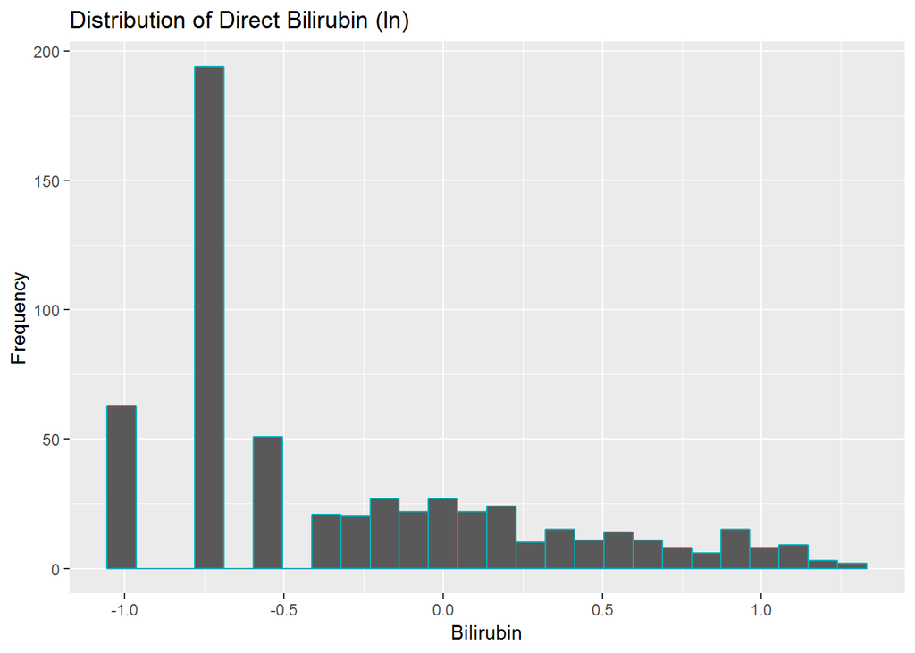

```r
liver_data %>%
ggplot(aes(log10(Dir_Bil))) +
geom_histogram(bins = 26, color = "#00AFBB") +
xlab("Bilirubin") +
ylab("Frequency") +
ggtitle("Distribution of Direct Bilirubin (ln)")
```

### **Alkaline Phosphotase** With this meause we can estimate, in general, **the liver health**. **More means disease**.

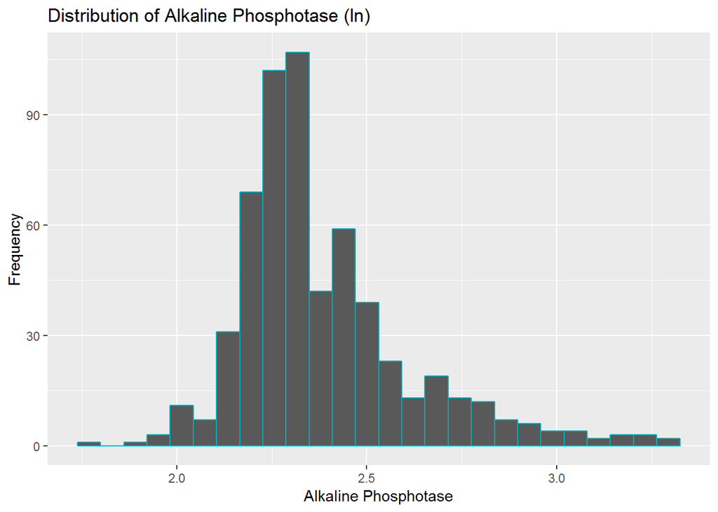

```r
liver_data %>%
ggplot(aes(log10(Alkphos))) +
geom_histogram(bins = 26, color = "#00AFBB") +
xlab("Alkaline Phosphotase") +
ylab("Frequency") +
ggtitle("Distribution of Alkaline Phosphotase (ln)")
```

### **Alamine Aminotransferase**

Natural component in the liver. Is tested in a liver panel.

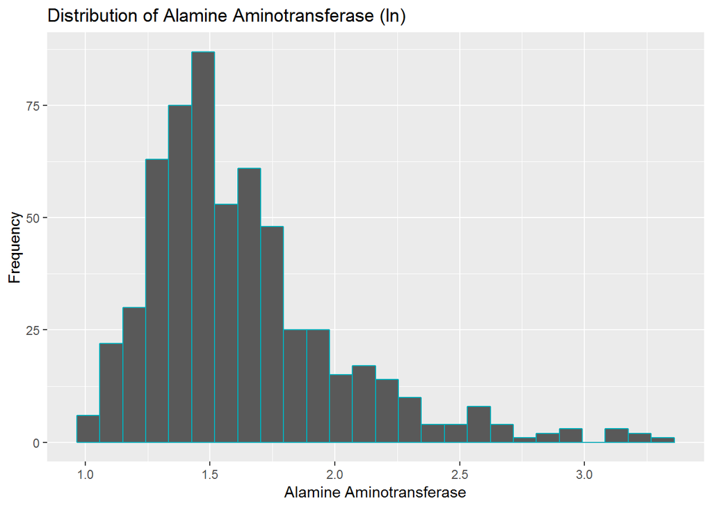

```r
liver_data %>%
ggplot(aes(log10(Alamine))) +
geom_histogram(bins = 26, color = "#00AFBB") +
xlab("Alamine Aminotransferase") +
ylab("Frequency") +
ggtitle("Distribution of Alamine Aminotransferase (ln)")
```

### **Aspartate Aminotransferase**

Natural component in the liver. Is tested in a liver panel.

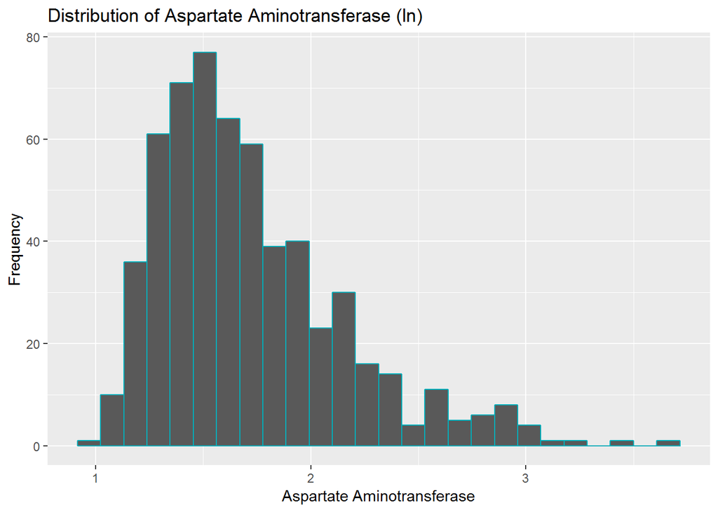

```r
liver_data %>%
ggplot(aes(log10(Aspartate))) +
geom_histogram(bins = 26, color = "#00AFBB") +
xlab("Aspartate Aminotransferase") +
ylab("Frequency") +
ggtitle("Distribution of Aspartate Aminotransferase (ln)")
```

### **Total Proteins**

Is a measure of globulin and albumin combined

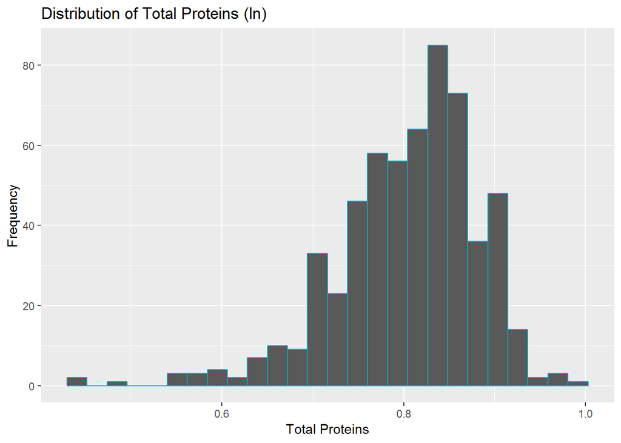

```r
liver_data %>%
ggplot(aes(log10(Tot_Prot))) +
geom_histogram(bins = 26, color = "#00AFBB") +
xlab("Total Proteins") +
ylab("Frequency") +
ggtitle("Distribution of Total Proteins (ln)")
```

### **Albumin**

Is a protein contained in the blood that gives structure to the vascular system.

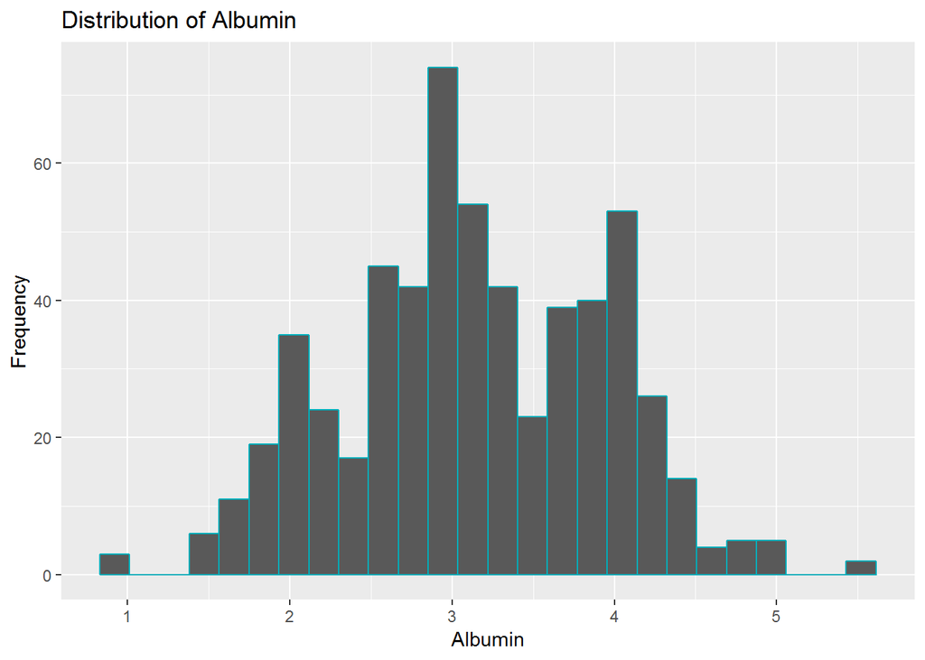

```r
liver_data %>%
ggplot(aes((Albumin))) +
geom_histogram(bins = 26, color = "#00AFBB") +
xlab("Albumin") +
ylab("Frequency") +
ggtitle("Distribution of Albumin")
```

### **Albumin-Globulin Ratio**

Is a general index of disesases.

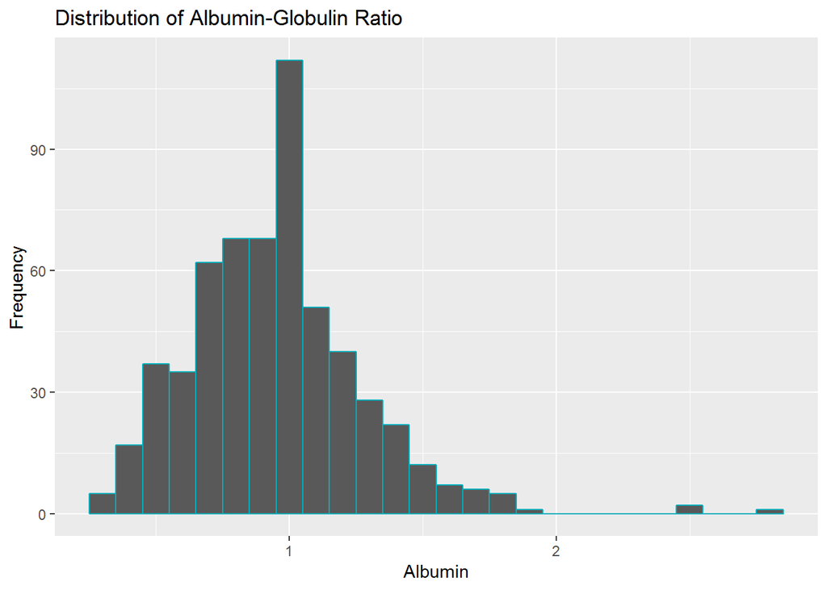

```r
liver_data %>%
ggplot(aes(A_G_Ratio)) +
geom_histogram(bins = 26, color = "#00AFBB") +
xlab("Albumin") +
ylab("Frequency") +
ggtitle("Distribution of Albumin-Globulin Ratio")
```

## *Model Approach*

In this project we want to see if the Logistic Regression can be used on this data set to help us predict liver disease.

```r
set.seed(455)
liver_data$Splits <- sample.split(liver_data, SplitRatio = 0.7)  #Index
liver_data <- liver_data %>% mutate_each(funs(log), -Age, -Sex, -Albumin, -A_G_Ratio,
    -Disease, -Splits)
train <- liver_data[liver_data$Splits == TRUE, ]  #training index
test <- liver_data[liver_data$Splits == FALSE, ]  #test indexes
```

### **Summary of training**

```r
summary(train)
```

```
##       Age            Sex               Tot_Bil           Dir_Bil
##  Min.   : 4.00   Length:371         Min.   :-0.6931   Min.   :-2.3026
##  1st Qu.:33.00   Class :character   1st Qu.:-0.2231   1st Qu.:-1.6094
##  Median :45.00   Mode  :character   Median : 0.0000   Median :-1.2040
##  Mean   :44.29                      Mean   : 0.4635   Mean   :-0.6463
##  3rd Qu.:57.00                      3rd Qu.: 0.9555   3rd Qu.: 0.2624
##  Max.   :90.00                      Max.   : 4.3175   Max.   : 2.9806
##
##     Alkphos         Alamine        Aspartate        Tot_Prot
##  Min.   :4.143   Min.   :2.303   Min.   :2.485   Min.   :1.281
##  1st Qu.:5.185   1st Qu.:3.219   1st Qu.:3.258   1st Qu.:1.758
##  Median :5.371   Median :3.611   Median :3.761   Median :1.872
##  Mean   :5.518   Mean   :3.794   Mean   :4.010   Mean   :1.856
##  3rd Qu.:5.697   3rd Qu.:4.151   3rd Qu.:4.500   3rd Qu.:1.974
##  Max.   :7.654   Max.   :7.396   Max.   :8.503   Max.   :2.262
##
##     Albumin        A_G_Ratio         Disease        Splits
##  Min.   :1.400   Min.   :0.3000   Min.   :0.0000   Mode:logical
##  1st Qu.:2.600   1st Qu.:0.7000   1st Qu.:0.0000   TRUE:371
##  Median :3.100   Median :0.9000   Median :1.0000
##  Mean   :3.138   Mean   :0.9474   Mean   :0.7197
##  3rd Qu.:3.800   3rd Qu.:1.1000   3rd Qu.:1.0000
##  Max.   :5.500   Max.   :2.8000   Max.   :1.0000
##                  NA's   :1
```

### **Logistic Model**

```r
fit <- glm(Disease ~ Age + Sex + Tot_Bil + Dir_Bil + Alkphos + Alamine + Aspartate +
    Tot_Prot + Albumin + A_G_Ratio, data = train, family = binomial(link = "logit"))
```

Coefficients:

```r
summary(fit)
```

```
##
## Call:
## glm(formula = Disease ~ Age + Sex + Tot_Bil + Dir_Bil + Alkphos +
##     Alamine + Aspartate + Tot_Prot + Albumin + A_G_Ratio, family = binomial(link = "logit"),
##     data = train)
##
## Deviance Residuals:
##     Min       1Q   Median       3Q      Max
## -2.4587  -0.9377   0.3171   0.8345   1.7431
##
## Coefficients:
##               Estimate Std. Error z value Pr(>|z|)
## (Intercept) -15.855900   4.120022  -3.848 0.000119 ***
## Age           0.021706   0.008757   2.479 0.013190 *
## SexM         -0.400726   0.326646  -1.227 0.219901
## Tot_Bil       0.427679   0.743300   0.575 0.565035
## Dir_Bil       0.171838   0.485116   0.354 0.723174
## Alkphos       0.946313   0.385611   2.454 0.014125 *
## Alamine       0.937354   0.321930   2.912 0.003595 **
## Aspartate     0.198097   0.288925   0.686 0.492943
## Tot_Prot      5.326228   2.391509   2.227 0.025938 *
## Albumin      -1.455345   0.764960  -1.903 0.057104 .
## A_G_Ratio     1.890692   1.222460   1.547 0.121953
## ---
## Signif. codes:  0 '***' 0.001 '**' 0.01 '*' 0.05 '.' 0.1 ' ' 1
##
## (Dispersion parameter for binomial family taken to be 1)
##
##     Null deviance: 439.54  on 369  degrees of freedom
## Residual deviance: 341.15  on 359  degrees of freedom
##   (1 observation deleted due to missingness)
## AIC: 363.15
##
## Number of Fisher Scoring iterations: 6
```

Pseudo R-Square and Log-Likelihoods: Usign the McFadden **R2** as a measure, the model explains just 22.5% of the disease classification.

```r
pR2(fit)
```

```
##          llh      llhNull           G2     McFadden         r2ML
## -170.5744495 -220.0989199   99.0489409    0.2250101    0.2348626
##         r2CU
##    0.3375943
```

Now we will use the Coefficient of Discrimination

```r
Test_Predictions <- data.frame(Probability = predict(fit, test, type = "response"))
Test_Predictions$Prediction <- ifelse(Test_Predictions > 0.5, 1, 0)
Test_Predictions$Disease <- test$Disease
accuracy <- mean(Test_Predictions$Disease == Test_Predictions$Prediction, na.rm = TRUE)
disease <- Test_Predictions$Probability[which(Test_Predictions$Disease == 1)]
non <- Test_Predictions$Probability[which(Test_Predictions$Disease == 0)]
Coef_Desc <- mean(disease, na.rm = TRUE) - mean(non, na.rm = TRUE)
print(accuracy)
```

```
## [1] 0.6889952
```

The Coefficient of Discrimination is=

```r
print(Coef_Desc)
```

```
## [1] 0.1420897
```

The accuracy of our model is=

```r
print(accuracy)
```

```
## [1] 0.6889952
```

The model accuracy tell us the time our model made the right prediction, meaning taht the **prediction was right 69% of the times**.

# **Final considerations and further discussion**

**This model can be use for early detection, not for diagnostic**.